# Transformaciones básicas con OpenCV

## 1 Introducción

En este documento aprenderemos a realizar **transformaciones geométricas básicas** sobre imágenes utilizando **OpenCV** en Python.  
Estas operaciones son esenciales en el preprocesamiento de imágenes antes de aplicar técnicas más avanzadas.

Transformaciones que cubriremos:

- **Redimensionamiento (resize)**
- **Recorte (crop)**
- **Rotación**
- **Traslación (desplazamiento)**

## 2 Configuración inicial

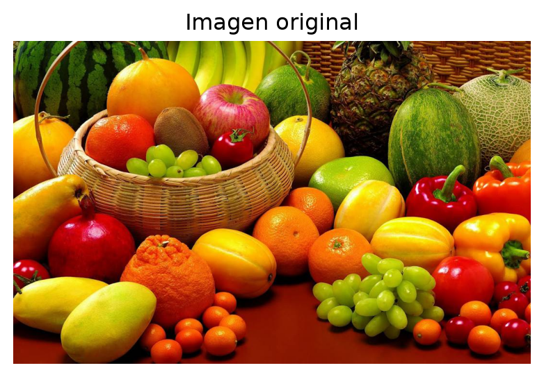

```python
import cv2
import numpy as np
import matplotlib.pyplot as plt
from pathlib import Path

# Función auxiliar para mostrar imágenes en color o grises
def mostrar_img(img, titulo="Imagen", cmap=None):
    plt.figure(figsize=(5,5))
    if len(img.shape) == 2:  # Escala de grises
        plt.imshow(img, cmap='gray')
    else:  # Color (BGR → RGB)
        plt.imshow(cv2.cvtColor(img, cv2.COLOR_BGR2RGB))
    plt.title(titulo)
    plt.axis('off')
    plt.show()

# Ruta a la carpeta de imágenes (ajustar según tu equipo)
carpeta = Path("imagenes")

# Cargar imagen de ejemplo
img = cv2.imread(str(carpeta / "frutas.jpg"))
mostrar_img(img, "Imagen original")
```

## 3 Redimensionamiento (Resize)

El **redimensionamiento** consiste en crear una imagen con un número diferente de filas y columnas. No cambia necesariamente el contenido de la imagen, sino la forma en que ese contenido se distribuye sobre una nueva cuadrícula de píxeles.

### 3.1 Factores de escala

Supongamos que la imagen original tiene:

- ancho $w$;
- alto $h$.

Y queremos obtener una imagen de:

- ancho $w'$;
- alto $h'$.

Los factores de escala son:

$$s_x=\frac{w'}{w},
\qquad
s_y=\frac{h'}{h}.$$

Estos números indican cuánto deben multiplicarse las coordenadas horizontales y verticales.

Por ejemplo, si una imagen de $100\times 50$ píxeles se transforma en una de $200\times 75$:

$$s_x=\frac{200}{100}=2,
\qquad
s_y=\frac{75}{50}=1.5.$$

Esto significa que:

- horizontalmente, la imagen se duplica;
- verticalmente, aumenta 1.5 veces.

Como $s_x \neq s_y$ , la proporción original cambia y la imagen puede verse estirada.

### 3.2 Mapeo directo

La matriz

$$\begin{bmatrix}
x'\\
y'
\end{bmatrix}
=
\begin{bmatrix}
s_x & 0\\
0 & s_y
\end{bmatrix}
\begin{bmatrix}
x\\
y
\end{bmatrix}$$

expresa cómo una posición $(x,y)$ de la imagen original se transforma en una posición $(x',y')$ de la imagen nueva.

La transformación equivale a:

$$x'=s_xx,
\qquad
y'=s_yy.$$

En el ejemplo anterior, el píxel ubicado en

$$(x,y)=(20,10)$$

se desplazaría a:

$$x'=2(20)=40,
\qquad
y'=1.5(10)=15.$$

Por tanto:

$$(20,10)\longrightarrow(40,15).$$

El problema de construir la imagen mediante este mapeo directo es que algunos píxeles de salida podrían quedarse sin valor.

Por ejemplo, al duplicar el tamaño de una imagen, un píxel original puede llegar a la posición $(0,0)$ y el siguiente a $(2,0)$. En ese caso, la posición $(1,0)$ de la imagen resultante quedaría sin asignar.

### 3.3 Mapeo inverso

Para evitar esos huecos, OpenCV recorre todos los píxeles de la imagen de salida y pregunta:

> ¿De qué coordenada de la imagen original debe provenir este píxel?

Para ello utiliza la transformación inversa:

$$\begin{bmatrix}
x\\
y
\end{bmatrix}
=
\begin{bmatrix}
1/s_x & 0\\
0 & 1/s_y
\end{bmatrix}
\begin{bmatrix}
x'\\
y'
\end{bmatrix}.$$

Es decir:

$$x=\frac{x'}{s_x},
\qquad
y=\frac{y'}{s_y}.$$

En el ejemplo, para calcular el píxel de salida ubicado en $(40,15)$:

$$x=\frac{40}{2}=20,
\qquad
y=\frac{15}{1.5}=10.$$

Así se determina que el píxel de salida $(40,15)$ debe tomar su información del píxel $(20,10)$ de la imagen original.

La ventaja del mapeo inverso es que **cada píxel de la imagen resultante recibe un valor**.

### 3.4 ¿Por qué se necesita interpolación?

Las coordenadas obtenidas mediante el mapeo inverso no siempre son números enteros.

Supongamos que un píxel de la imagen de salida se mapea a la posición:

$$(x,y)=(20.4,10.7).$$

En una imagen digital no existe literalmente un píxel en la posición $(20.4,10.7)$. Solo existen píxeles con coordenadas enteras, como:

$$(20,10),\quad
(21,10),\quad
(20,11),\quad
(21,11).$$

Por ello, es necesario **estimar** el valor que debe asignarse mediante algún método de interpolación.

#### 3.4.1 Vecino más cercano: `INTER_NEAREST`

Este método selecciona el píxel más cercano a la coordenada calculada.

Para la posición $(20.4,10.7)$, podría seleccionar el píxel:

$$(20,11).$$

Es un método muy rápido, pero al ampliar una imagen puede producir:

- bloques visibles;
- bordes escalonados;
- pixelación;
- aliasing.

Es especialmente útil cuando no deben generarse valores intermedios, por ejemplo, al redimensionar máscaras de segmentación que contienen etiquetas discretas.

#### 3.4.2 Interpolación bilineal: `INTER_LINEAR`

Este método utiliza los cuatro píxeles que rodean la posición calculada:

$$(20,10),\quad
(21,10),\quad
(20,11),\quad
(21,11).$$

El nuevo valor se obtiene mediante un promedio ponderado. Los píxeles más cercanos a la posición calculada reciben un peso mayor.

Produce resultados más suaves que el vecino más cercano y es una opción común para ampliar fotografías e imágenes generales.

#### 3.4.3 Interpolación por área: `INTER_AREA`

Este método considera el área cubierta por los píxeles originales y combina sus valores.

Es especialmente conveniente al **reducir** imágenes, porque varios píxeles de la imagen original deben resumirse en un solo píxel de la imagen resultante.

Ayuda a disminuir problemas como:

- aliasing;
- patrones artificiales;
- bordes dentados;
- pérdida irregular de detalles.

### 3.5 Idea intuitiva

La imagen original puede imaginarse como un dibujo colocado sobre una cuadrícula:

- al ampliar la imagen, la nueva cuadrícula tiene más celdas;
- al reducirla, la nueva cuadrícula tiene menos celdas;
- el mapeo inverso determina qué posición original corresponde a cada celda nueva;
- la interpolación decide qué intensidad o color debe asignarse.

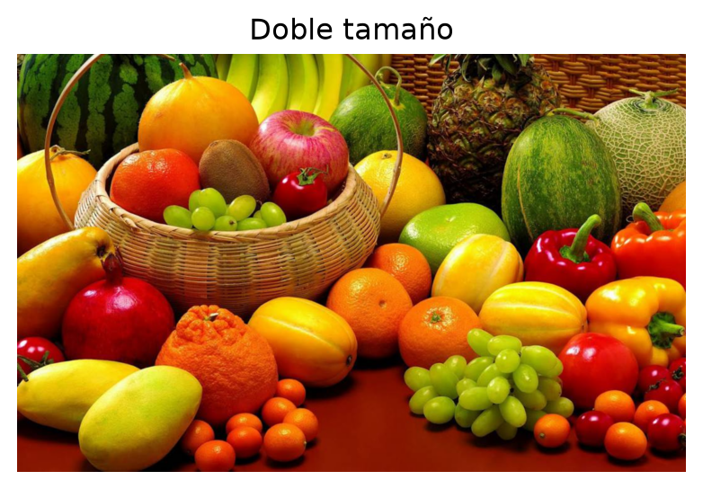

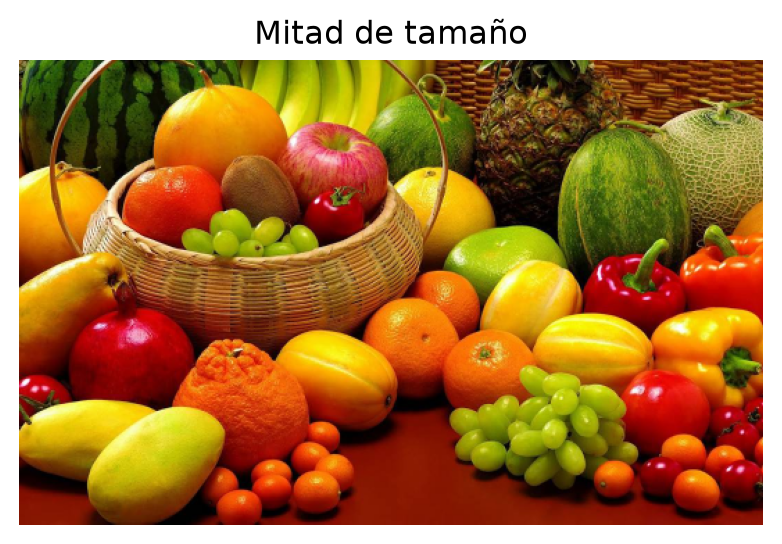

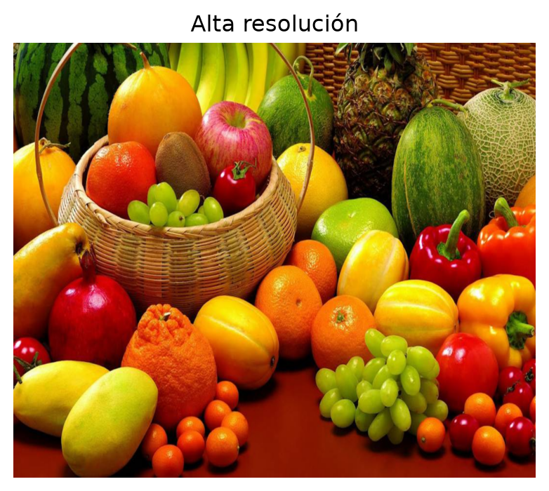

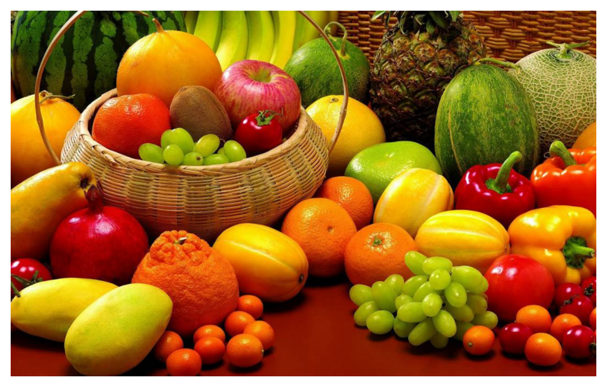

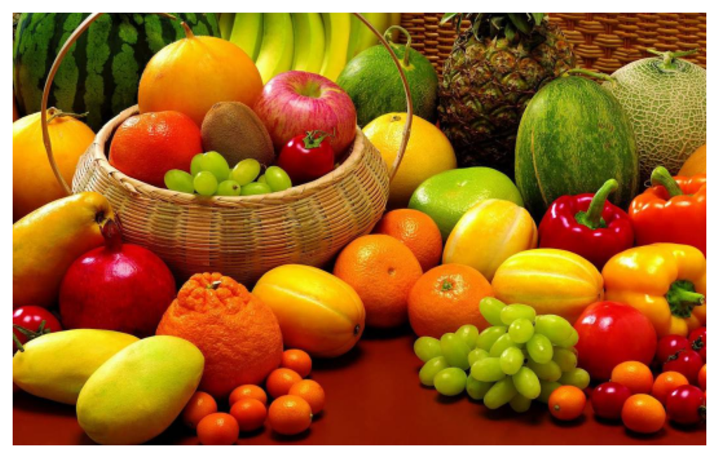

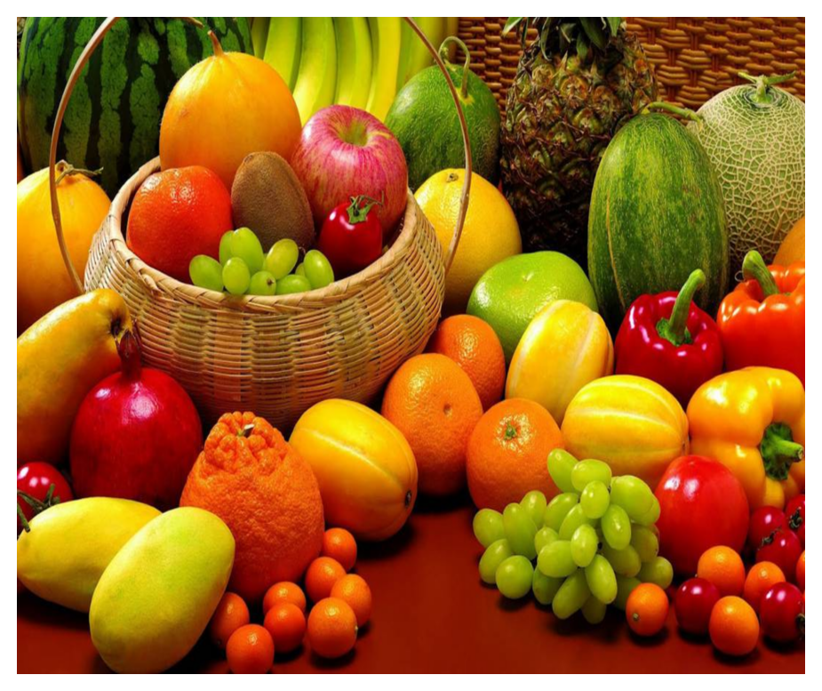

```
(670, 1072, 3)
(1340, 2144, 3)
(335, 536, 3)
(1340, 1608, 3)
```

```python
# Imagen al doble de tamaño
img_doble = cv2.resize(img, None, fx=2, fy=2, interpolation=cv2.INTER_LINEAR)
mostrar_img(img_doble, "Doble tamaño")

# Imagen a la mitad
img_mitad = cv2.resize(img, None, fx=0.5, fy=0.5, interpolation=cv2.INTER_AREA)
mostrar_img(img_mitad, "Mitad de tamaño")

# imagen alta
img_alta = cv2.resize(img, None, fx=1.5, fy=2, interpolation=cv2.INTER_LINEAR)
mostrar_img(img_alta, "Alta resolución")

plt.imshow(cv2.cvtColor(img_doble, cv2.COLOR_BGR2RGB))
plt.axis('off')
plt.show()

plt.imshow(cv2.cvtColor(img_mitad, cv2.COLOR_BGR2RGB))
plt.axis('off')
plt.show()

plt.imshow(cv2.cvtColor(img_alta, cv2.COLOR_BGR2RGB))
plt.axis('off')
plt.show()

print(img.shape)  # Dimensiones originales
print(img_doble.shape)  # Dimensiones de la imagen al doble
print(img_mitad.shape)  # Dimensiones de la imagen a la mitad
print(img_alta.shape)  # Dimensiones de la imagen alta
```

## 4 Recorte (Crop)

Un **crop** (corte) consiste en extraer una **Región de Interés (ROI)** de la imagen.  
Si la imagen original $I$ tiene dimensiones $h \times w$ (alto por ancho), entonces un crop rectangular definido por:

- filas: desde $y_0$ hasta $y_1$
- columnas: desde $x_0$ hasta $x_1$

se expresa como una submatriz:

$$I_{\text{crop}} = I[y_0:y_1,\; x_0:x_1]$$

En Python/NumPy, los intervalos son semiabiertos: incluye $y_0$ y excluye $y_1$ (igual para $x$).  
Esto produce una imagen con dimensiones:

$$h' = y_1 - y_0,\qquad w' = x_1 - x_0$$

### 4.1 Implementación (NumPy/OpenCV)

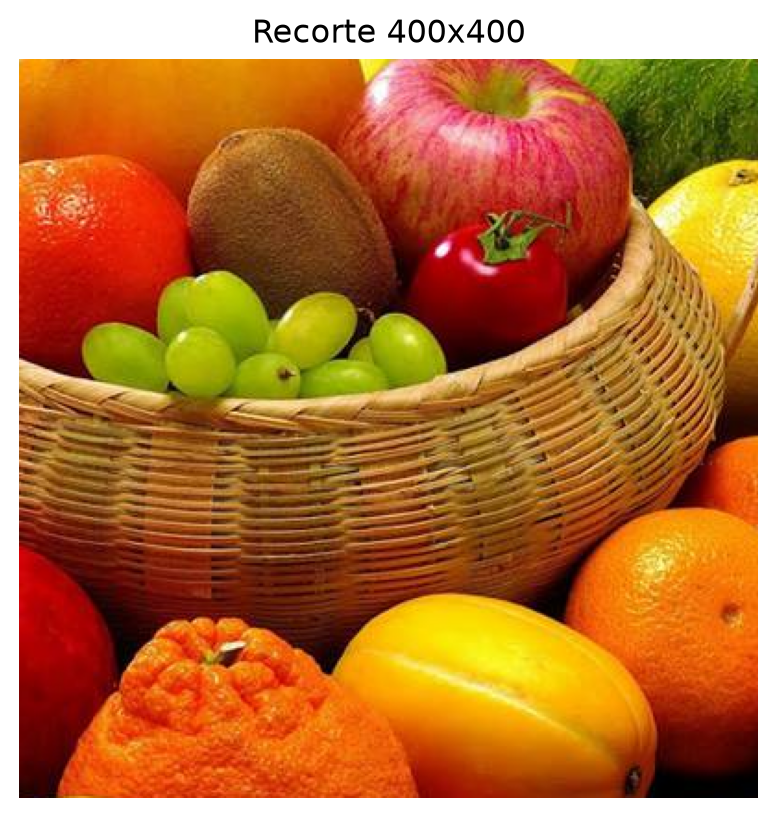

```python
# Recorte de una región específica (y1:y2, x1:x2)
crop = img[100:500, 200:600]
mostrar_img(crop, "Recorte 400x400")
```

## 5 Rotación

Una **rotación** en 2D transforma un punto $(x,y)$ a $(x',y')$.  
Si rotamos un ángulo $\theta$ alrededor del **origen**, la transformación se expresa como:

$$\begin{bmatrix}
x' \\
y'
\end{bmatrix}
=
\underbrace{
\begin{bmatrix}
\cos\theta & -\sin\theta \\
\sin\theta & \cos\theta
\end{bmatrix}
}_{R(\theta)}
\begin{bmatrix}
x \\
y
\end{bmatrix}$$

En imágenes, normalmente no queremos rotar respecto al origen $(0,0)$, sino respecto al **centro** $(c_x, c_y)$.  
Para rotar alrededor del centro, se realiza esta idea:

1. **Trasladar** el centro al origen: $(x,y)\to(x-c_x, y-c_y)$
2. **Rotar** con $R(\theta)$
3. **Regresar** el origen al centro: $(x,y)\to(x+c_x, y+c_y)$

Esa combinación se puede escribir como una transformación afín:

$$\begin{bmatrix}
x' \\
y'
\end{bmatrix}
=
\begin{bmatrix}
a & b & t_x \\
c & d & t_y
\end{bmatrix}
\begin{bmatrix}
x \\
y \\
1
\end{bmatrix}$$

En el caso de rotación con escala $s$, OpenCV usa:

$$a = s\cos\theta,\quad b = s\sin\theta,\quad
c = -s\sin\theta,\quad d = s\cos\theta$$

y el vector de traslación $(t_x,t_y)$ se elige para que el centro $(c_x,c_y)$ permanezca fijo:

$$t_x = (1-a)c_x - b c_y,\qquad
t_y = b c_x + (1-d)c_y$$

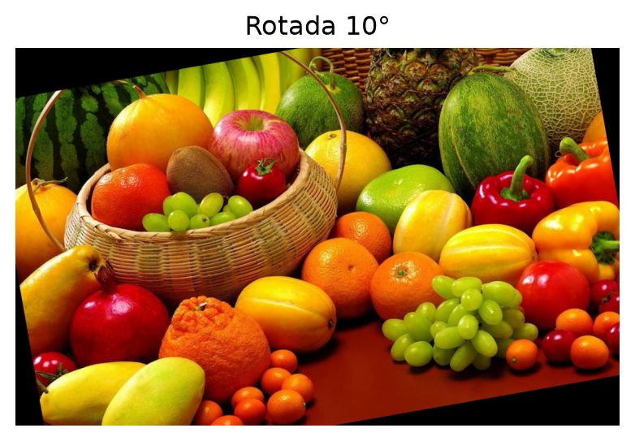

```python
# Obtener dimensiones
(h, w) = img.shape[:2]
centro = (w // 2, h // 2)

# Matriz de rotación (10 grados)
M_rot = cv2.getRotationMatrix2D(centro, 10, 1.0)
rotada = cv2.warpAffine(img, M_rot, (w, h))
mostrar_img(rotada, "Rotada 10°")
```

## 6 Traslación (Desplazamiento)

Una **traslación** desplaza todos los pixeles de la imagen una cantidad fija. Si movemos **50 px a la derecha** y **30 px hacia abajo**, entonces:

- $x' = x + 50$
- $y' = y + 30$

En OpenCV, esto se implementa con una matriz afín $2\times 3$:

$$M =
\begin{bmatrix}
1 & 0 & 50 \\
0 & 1 & 30
\end{bmatrix}$$

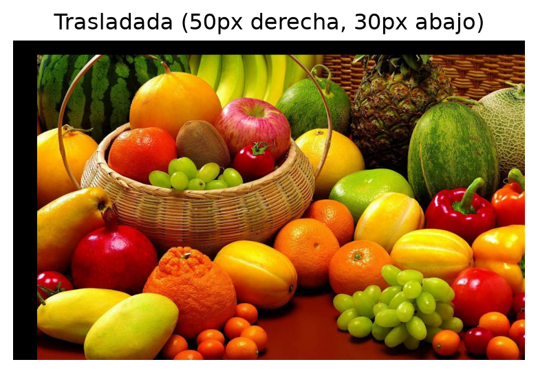

```python
# Matriz de traslación: mover 50 px a la derecha y 30 px abajo
M_tras = np.float32([[1, 0, 50], [0, 1, 30]])
trasladada = cv2.warpAffine(img, M_tras, (w, h))
mostrar_img(trasladada, "Trasladada (50px derecha, 30px abajo)")
```

## 7 Operaciones aritméticas y lógicas

Además de transformar la geometría de una imagen, también podemos combinar sus píxeles mediante operaciones aritméticas y lógicas. Estas operaciones son útiles para mezclar imágenes, comparar capturas y construir regiones de interés.

### 7.1 Adición de imágenes

La adición suma los valores de intensidad de dos imágenes posición por posición:

$$C(x,y)=A(x,y)+B(x,y)$$

En OpenCV conviene utilizar `cv2.add()` en lugar del operador `+`. La función de OpenCV realiza una suma saturada: si el resultado supera el máximo permitido por el tipo de dato, se conserva ese máximo en lugar de producir un desbordamiento.

Para observar el efecto, se combinan una imagen original y una versión más clara de la misma imagen.

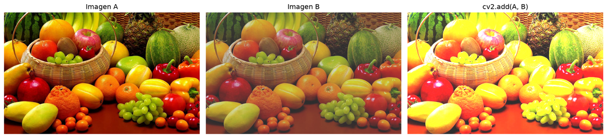

```python
# Adición píxel a píxel con saturación
imagen_a = img.copy()
imagen_b = cv2.convertScaleAbs(img, alpha=0.65, beta=45)
imagen_sumada = cv2.add(imagen_a, imagen_b)

fig, ejes = plt.subplots(1, 3, figsize=(15, 4))
for eje, imagen, titulo in zip(
    ejes,
    [imagen_a, imagen_b, imagen_sumada],
    ["Imagen A", "Imagen B", "cv2.add(A, B)"]
):
    eje.imshow(cv2.cvtColor(imagen, cv2.COLOR_BGR2RGB))
    eje.set_title(titulo)
    eje.axis("off")
plt.tight_layout()
plt.show()
```

La adición directa no es lo mismo que una mezcla ponderada. En una mezcla ponderada, cada imagen aporta una fracción de su intensidad:

$$C(x,y)=\alpha A(x,y)+\beta B(x,y)+\gamma$$

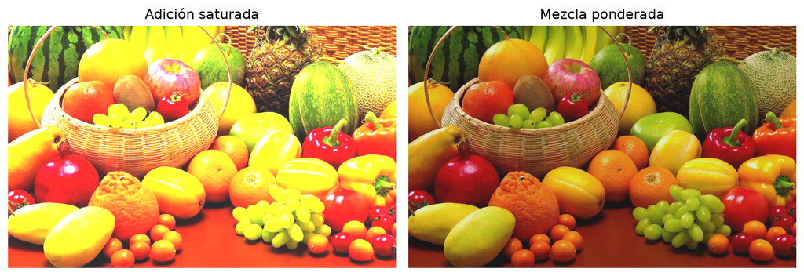

```python
mezcla = cv2.addWeighted(imagen_a, 0.5, imagen_b, 0.5, 0)

fig, ejes = plt.subplots(1, 2, figsize=(10, 4))
for eje, imagen, titulo in zip(
    ejes,
    [imagen_sumada, mezcla],
    ["Adición saturada", "Mezcla ponderada"]
):
    eje.imshow(cv2.cvtColor(imagen, cv2.COLOR_BGR2RGB))
    eje.set_title(titulo)
    eje.axis("off")
plt.tight_layout()
plt.show()
```

### 7.2 Sustracción de imágenes

La sustracción calcula la diferencia entre dos imágenes alineadas:

$$C(x,y)=A(x,y)-B(x,y)$$

`cv2.subtract()` también utiliza saturación: los resultados negativos se llevan a cero. Para visualizar cambios independientemente de su signo, suele ser más conveniente utilizar `cv2.absdiff()`.

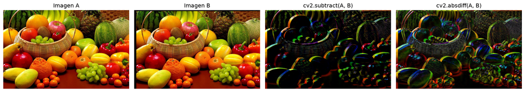

```python
# Creamos una segunda captura desplazando ligeramente la imagen original.
imagen_movida = cv2.warpAffine(
    img,
    np.float32([[1, 0, 18], [0, 1, 8]]),
    (img.shape[1], img.shape[0])
)
diferencia_resta = cv2.subtract(img, imagen_movida)
diferencia_absoluta = cv2.absdiff(img, imagen_movida)

fig, ejes = plt.subplots(1, 4, figsize=(16, 4))
for eje, imagen, titulo in zip(
    ejes,
    [img, imagen_movida, diferencia_resta, diferencia_absoluta],
    ["Imagen A", "Imagen B", "cv2.subtract(A, B)", "cv2.absdiff(A, B)"]
):
    eje.imshow(cv2.cvtColor(imagen, cv2.COLOR_BGR2RGB))
    eje.set_title(titulo)
    eje.axis("off")
plt.tight_layout()
plt.show()
```

La diferencia absoluta permite detectar movimiento o cambios entre dos capturas. En una aplicación real, después de calcularla se puede convertir a escala de grises y aplicar un umbral para conservar únicamente los cambios importantes.

### 7.3 Operaciones bit a bit

Las operaciones bit a bit trabajan sobre los bits de cada píxel. En procesamiento de imágenes se utilizan principalmente con máscaras binarias, cuyos píxeles suelen tener solamente los valores 0 y 255.

- `cv2.bitwise_and()` conserva las regiones presentes en ambas máscaras.
- `cv2.bitwise_or()` conserva las regiones presentes en al menos una máscara.
- `cv2.bitwise_xor()` conserva las regiones presentes en una sola de las máscaras.
- `cv2.bitwise_not()` invierte una máscara.

El siguiente ejemplo utiliza un círculo y un rectángulo para hacer visibles las regiones de intersección, unión y diferencia.

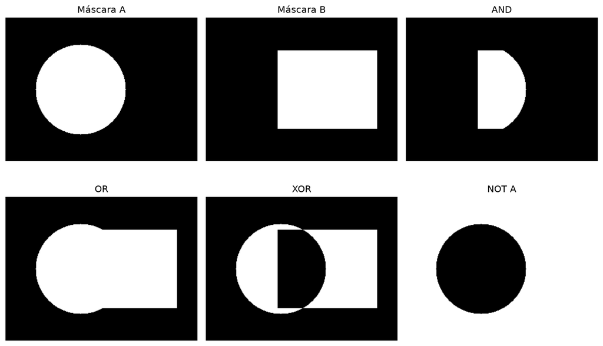

```python
# Máscaras binarias sintéticas para visualizar las operaciones lógicas.
alto_mascara, ancho_mascara = 240, 320
mascara_a = np.zeros((alto_mascara, ancho_mascara), dtype=np.uint8)
mascara_b = np.zeros((alto_mascara, ancho_mascara), dtype=np.uint8)
cv2.circle(mascara_a, (125, 120), 75, 255, -1)
cv2.rectangle(mascara_b, (120, 55), (285, 185), 255, -1)

operaciones = [
    (mascara_a, "Máscara A"),
    (mascara_b, "Máscara B"),
    (cv2.bitwise_and(mascara_a, mascara_b), "AND"),
    (cv2.bitwise_or(mascara_a, mascara_b), "OR"),
    (cv2.bitwise_xor(mascara_a, mascara_b), "XOR"),
    (cv2.bitwise_not(mascara_a), "NOT A"),
]

fig, ejes = plt.subplots(2, 3, figsize=(11, 7))
for eje, (resultado, titulo) in zip(ejes.ravel(), operaciones):
    eje.imshow(resultado, cmap="gray", vmin=0, vmax=255)
    eje.set_title(titulo)
    eje.axis("off")
plt.tight_layout()
plt.show()
```

En una máscara binaria, el valor 0 representa una posición excluida y el valor 255 una posición seleccionada. Por eso, `AND` equivale a una intersección, `OR` a una unión y `XOR` a las regiones que no se superponen.

## 8 Conclusión

En este ejemplo hemos cubierto transformaciones geométricas básicas que son fundamentales para el preprocesamiento de imágenes:

- **Resize** para ajustar el tamaño.
- **Crop** para enfocar regiones de interés.
- **Rotación y traslación** para reposicionar la imagen.
- **Adición y sustracción** para combinar imágenes o detectar cambios.
- **Operaciones bit a bit** para combinar máscaras binarias.

Estas operaciones forman la base para tareas más complejas como la alineación, el registro, la detección de movimiento y la segmentación de imágenes.